# Lyft Bay Wheels Data Exploration

## by Wakana Morlan

## Investigation Overview

In this investigation, I wanted to look at the difference in the service usage of Bay Wheel by user type. The main focus was the trip distance, trip duration and the relationship of these 2 variables by user type.

## Dataset Overview

This document explores a dataset containing 94802 trip records of BayWheels in January 2018. The original data is available to download from [here](https://www.lyft.com/bikes/bay-wheels/system-data).

## Propotion of Subscriber v.s. Customer

Majority of the rides are made by subscribers. This totally makes sense that subscribers have an unlimited ride for up to 45 minutes. I wish I could identify the individual users so that I can understand each user's frequency of the service use. Unfortunately, such information is not available in this dataset.

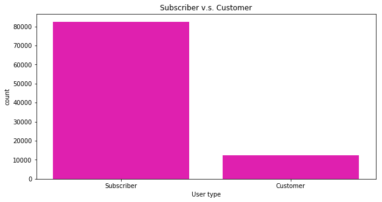

```python
plt.figure(figsize=[10,5])
sb.countplot(data = BayWheels, x='user_type', color = base_color)
plt.title('Subscriber v.s. Customer')
plt.xlabel('User type');
```

## Relationship between trip duration and distance by user type

- Subscribers tend to have a shorter duration and slightly longer distance trip than customers for the trip lasted for less than 1 hour.
- Even though subscribers have an unlimited ride for 45 minutes, the majority of their trips are within 30 minutes.
- Customers tend to have a longer duration and longer distance trip than subscriber for the trip lasted for over 1 hour, even though it cost customers more than what costed subscribers.
- Customers tend to ride the bike for a longer period of time.

### Overview

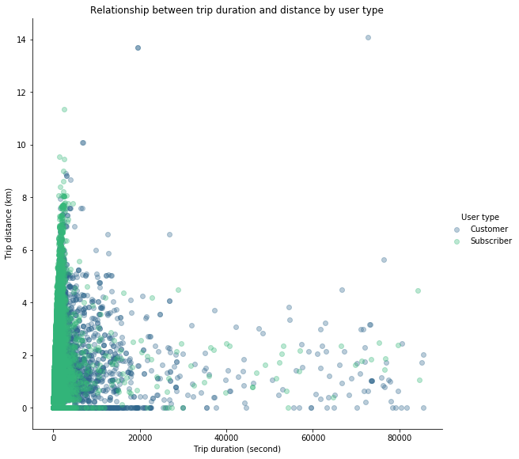

```python
g= sb.FacetGrid(data = BayWheels, hue = 'user_type', height = 8, palette='viridis', hue_order = ["Customer","Subscriber"])
g.map(plt.scatter, 'duration_sec', 'distance', alpha =  1/3)
g.add_legend()
g._legend.set_title('User type')
plt.title('Relationship between trip duration and distance by user type')
plt.xlabel('Trip duration (second)')
plt.ylabel('Trip distance (km)');
```

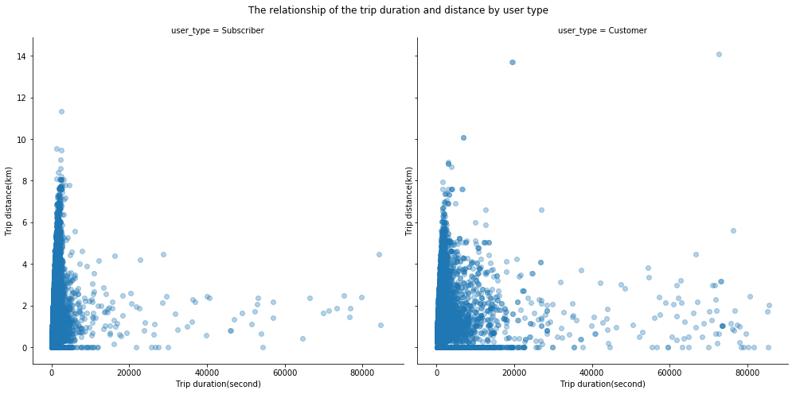

```python
g = sb.FacetGrid(data = BayWheels, col = 'user_type', height = 7, margin_titles=True)
g.map(plt.scatter, 'duration_sec', 'distance', alpha =  1/3)

plt.subplots_adjust(top=0.9)
g.fig.suptitle('The relationship of the trip duration and distance by user type')

g.axes[0,0].set_xlabel('Trip duration(second)')
g.axes[0,1].set_xlabel('Trip duration(second)')

g.axes[0,0].set_ylabel('Trip distance(km)')
g.axes[0,1].set_ylabel('Trip distance(km)');
```

### Trips lasted less than 1 hour

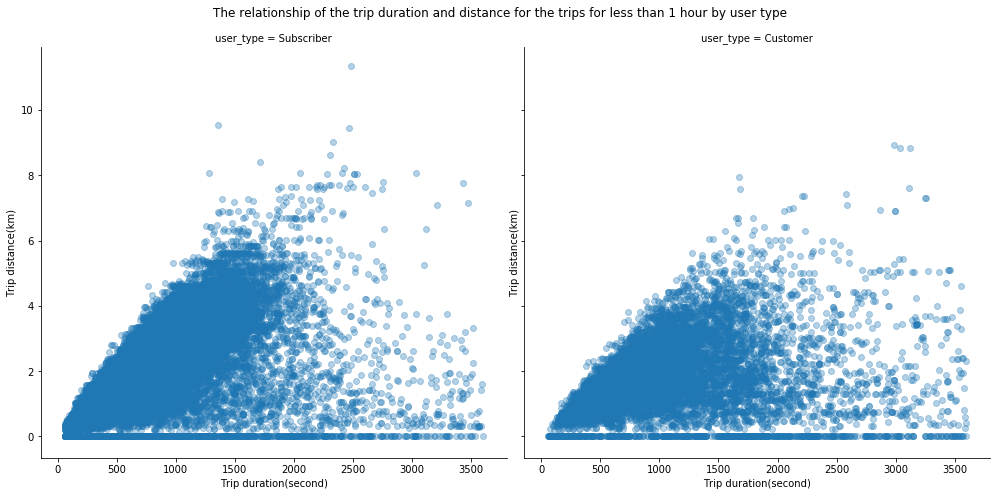

```python
#Trips less than 1 hour
g = sb.FacetGrid(data = BayWheels_1hour, col = 'user_type', height = 7, margin_titles=True)
g.map(plt.scatter, 'duration_sec', 'distance', alpha =  1/3)
plt.subplots_adjust(top=0.9)
g.fig.suptitle('The relationship of the trip duration and distance for the trips for less than 1 hour by user type')

g.axes[0,0].set_xlabel('Trip duration(second)')
g.axes[0,1].set_xlabel('Trip duration(second)')

g.axes[0,0].set_ylabel('Trip distance(km)')
g.axes[0,1].set_ylabel('Trip distance(km)');
```

### Trips lasted pver 1 hour

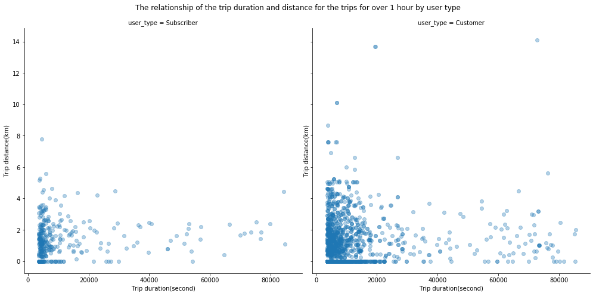

```python
#Trips over 1 hour
g = sb.FacetGrid(data = BayWheels_over1, col = 'user_type', height = 7, margin_titles=True)
g.map(plt.scatter, 'duration_sec', 'distance', alpha =  1/3)
plt.subplots_adjust(top=0.9)
g.fig.suptitle('The relationship of the trip duration and distance for the trips for over 1 hour by user type')

g.axes[0,0].set_xlabel('Trip duration(second)')
g.axes[0,1].set_xlabel('Trip duration(second)')

g.axes[0,0].set_ylabel('Trip distance(km)')
g.axes[0,1].set_ylabel('Trip distance(km)');
```

## The stations most used for round trips by user type

### Overall

- 2207 trips, which of 2.3% of the total trips are round trips (These are the trips started and ended at the same station.)
- The most used station for round trips is the Embarcadero at Sansome St followed by Central Ave at Fell and San Francisco Ferry Building. The Embarcadero at Sansome St and San Francisco Ferry Building make sense because both are near the station of public transportation and located in downtown.

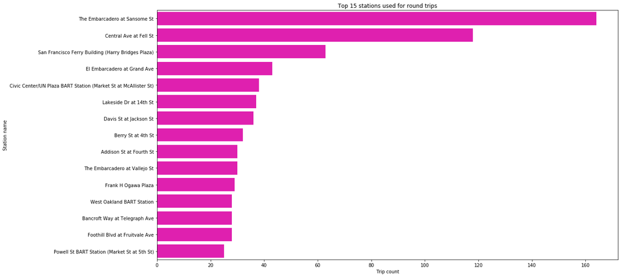

```python
plt.figure(figsize=[18,10])
sb.barplot(data = round_trip, y='start_station_name', x='trip_count', color = base_color)
plt.title('Top 15 stations used for round trips')
plt.xlabel('Trip count')
plt.ylabel('Station name');
```

# Subscribers vs Customers

- Both subscribers and customers made round trips, however, the purpose of the round trip differed by user type.
- The stations used the most for roundtrips by customers are The Embacadero at Sansome St station and Central Ave at Fell St station and both are located near sightseeing or bike riding spots.

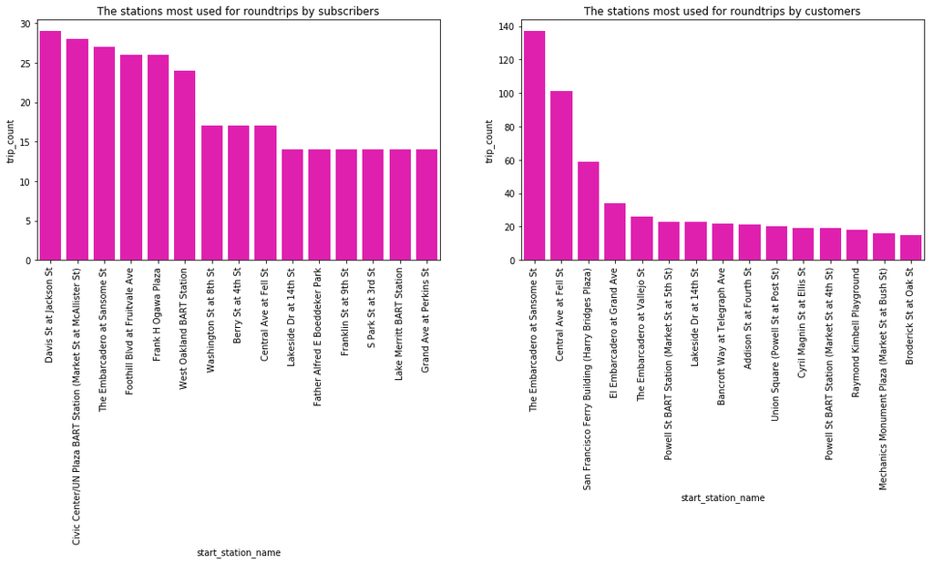

```python
plt.figure(figsize=[18,5])

#Plot1: Subscriber's roundtrip
plt.subplot(1,2,1)
sb.barplot(data = round_trip_subsc, x = 'start_station_name', y= 'trip_count', color= base_color)
plt.xticks (rotation = 90)
plt.title('The stations most used for roundtrips by subscribers')

#Plot2: Customer's roundtrip
plt.subplot(1,2,2)
sb.barplot(data = round_trip_cust, x = 'start_station_name', y = 'trip_count', color = base_color)
plt.title('The stations most used for roundtrips by customers')
plt.xticks (rotation = 90);
```

## Summary of Findings

- Subscribers are purpose-driven riders. As most of their tips are short, mostly within 30minutes, and made around downtown, they use BayWeel for commuting.
- Customers are casual riders. Since they enjoy riding, they tend to make a longer duration and distance trip.